# 3-phase VSI

The three-phase inverter as shown in the figure is operated in 180-degree conduction mode. The frequency of the phase voltage $v_{an}$ is $50\,$Hz. The circuit parameters are $V_{dc}=600\,$V, $L=10\,$mH. Under steady state, assuming the average inductor current to be zero, what is the diode peak current?

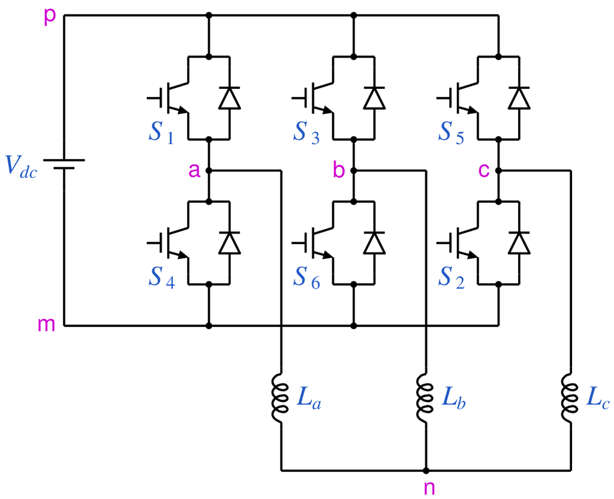

```python
from IPython.display import Image
Image(filename =r'VSI_3ph_14_fig_1.png', width=400)
```

```python
# run this cell to view the circuit file.
%pycat VSI_3ph_14_orig.in
```

```python
import gseim_calc as calc
s_Vdc = "600"
s_f_clock = "50"
s_L = "10e-3"

f_clock = float(s_f_clock)
T = 1/f_clock
s_2T = ("%11.4E"%(2.0*T)).strip()

phi = 180.0
D1 = phi/360.0
s_D1 = ("%11.4E"%(D1)).strip()

l = [
  ('$Vdc', s_Vdc),
  ('$L', s_L),
  ('$f_clock', s_f_clock),
  ('$D1', s_D1),
  ('$2T', s_2T),
]
calc.replace_strings_1("VSI_3ph_14_orig.in", "VSI_3ph_14.in", l)
print('VSI_3ph_14.in is ready for execution')
```

```
VSI_3ph_14.in is ready for execution
```

**Execute the following cell to run GSEIM on VSI_3ph_14.in.**

```python
import os
import dos_unix
# uncomment for windows:
#dos_unix.d2u("VSI_3ph_14.in")
os.system('run_gseim VSI_3ph_14.in')
```

```
Circuit: filename = VSI_3ph_14.in
main: calling solve_sss
solve_sss starting: sss_n_st: 3
solve_sss_ex: sss_iter_newton=0, rhs_sss_norm=3.7164e+00, sss_period_1_compute=4.0000e-02
solve_sss_ex: sss_iter_newton=1, rhs_sss_norm=2.4853e-11, sss_period_1_compute=4.0000e-02
solve_sss_ex: sss_iter_newton=2, rhs_sss_norm=5.5038e-14, sss_period_1_compute=4.0000e-02
solve_sss_ex: calling sss_solve_trns_ex for one more trns step
Transient simulation starts...
i=0
i=10000
GSEIM: Program completed.
```

```
0
```

The circuit file (`VSI_3ph_14.in`) is created in the same directory as that used for launching Jupyter notebook. The last step (i.e., running `GSEIM` on `VSI_3ph_14.in`) creates data files called `VSI_3ph_14_1.dat`, etc. in the same directory. We can now use the python code below to compute/plot the various quantities of interest.

```
filename: VSI_3ph_14_2.dat
filename: VSI_3ph_14_1.dat
filename: VSI_3ph_14_3.dat
ID1_max:  1.3254E+02
```

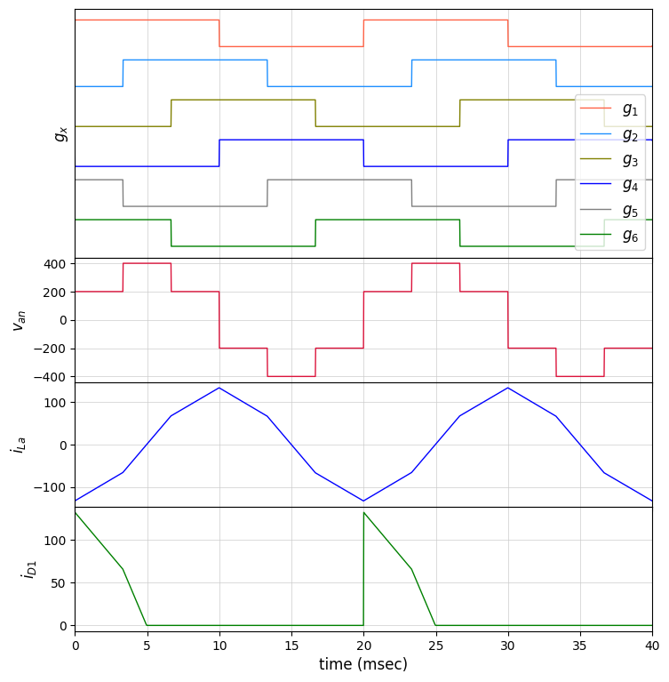

```python
import numpy as np
import matplotlib.pyplot as plt
import gseim_calc as calc
from setsize import set_size

f_hz = 50.0
T = 1.0/f_hz

slv = calc.slv("VSI_3ph_14.in")

i_slv = 0
i_out = 1
filename = slv.l_filename_all[i_slv][i_out]
print('filename:', filename)
u1 = np.loadtxt(filename)
t1 = u1[:, 0]

v_an = slv.get_array_double(i_slv,i_out,"v_an",u1)

i_out = 0
filename = slv.l_filename_all[i_slv][i_out]
print('filename:', filename)
u2 = np.loadtxt(filename)
t2 = u2[:, 0]

g1 = slv.get_array_double(i_slv,i_out,"g1",u2)
g2 = slv.get_array_double(i_slv,i_out,"g2",u2)
g3 = slv.get_array_double(i_slv,i_out,"g3",u2)
g4 = slv.get_array_double(i_slv,i_out,"g4",u2)
g5 = slv.get_array_double(i_slv,i_out,"g5",u2)
g6 = slv.get_array_double(i_slv,i_out,"g6",u2)

i_out = 2
filename = slv.l_filename_all[i_slv][i_out]
print('filename:', filename)
u3 = np.loadtxt(filename)
t3 = u3[:, 0]

ILa = slv.get_array_double(i_slv,i_out,"ILa",u3)
ID1 = slv.get_array_double(i_slv,i_out,"ID1",u3)

l1 = calc.min_max_1(t3, ID1, 0.0, 2.0*T)
print('ID1_max:', "%11.4E"%l1[1])

fig, ax = plt.subplots(4, sharex=False, gridspec_kw={'height_ratios': [2, 1, 1, 1]})
plt.subplots_adjust(wspace=0, hspace=0.0)

set_size(6.5, 7, ax[0])

for i in range(4):
    ax[i].set_xlim(left=0.0, right=2.0*T*1e3)
    ax[i].grid(color='#CCCCCC', linestyle='solid', linewidth=0.5)

ax[0].set_ylabel(r'$g_x$'   , fontsize=12)
ax[1].set_ylabel(r'$v_{an}$', fontsize=12)
ax[2].set_ylabel(r'$i_{La}$', fontsize=12)
ax[3].set_ylabel(r'$i_{D1}$', fontsize=12)

for i in range(3):
    ax[i].tick_params(labelbottom=False)

color1 = "tomato"
color2 = "dodgerblue"
color3 = "olive"
color4 = "blue"
color5 = "grey"
color6 = "green"
color7 = "crimson"

dy = 1.5

ax[0].plot(t2*1e3, (g1       ), color=color1, linewidth=1.0, label="$g_1$")
ax[0].plot(t2*1e3, (g2 -   dy), color=color2, linewidth=1.0, label="$g_2$")
ax[0].plot(t2*1e3, (g3 - 2*dy), color=color3, linewidth=1.0, label="$g_3$")
ax[0].plot(t2*1e3, (g4 - 3*dy), color=color4, linewidth=1.0, label="$g_4$")
ax[0].plot(t2*1e3, (g5 - 4*dy), color=color5, linewidth=1.0, label="$g_5$")
ax[0].plot(t2*1e3, (g6 - 5*dy), color=color6, linewidth=1.0, label="$g_6$")

ax[0].tick_params(left = False)
ax[0].set_yticks([])

ax[1].plot(t1*1e3, v_an, color=color7, linewidth=1.0, label="$v_{an}$")
ax[2].plot(t3*1e3, ILa , color=color4, linewidth=1.0, label="$i_{La}$")
ax[3].plot(t3*1e3, ID1 , color=color6, linewidth=1.0, label="$i_{D1}$")

ax[3].set_xlabel('time (msec)', fontsize=12)

ax[0].legend(loc = 'lower right',frameon = True, fontsize = 10, title = None,
    markerfirst = True, markerscale = 1.0, labelspacing = 0.5, columnspacing = 2.0,
    prop = {'size' : 12})

#plt.tight_layout()
plt.show()
```

This notebook was contributed by **Prof. Nakul Narayanan K**, Govt. Engineering College, Thrissur. He may be contacted at nakul@gectcr.ac.in.